# PA02 · Medio físico, variables ambientales, análisis espacial, correlación, regresión, manuscrito y presentación oral Biogeografía (GEO-131) Universidad Autónoma de Santo Domingo (UASD)

El Tali

2026-03-10

# Fecha/hora de entrega

[**VER PORTAL DE LA ASIGNATURA**](https://github.com/biogeografia-202601)

## Objetivos

El objetivo de esta práctica es que demuestres o mejores:

- tus capacidades de **trabajar íntegramente en R** con datos geoespaciales;
- tus capacidades de **extraer valores de variables ambientales en puntos**;
- tus capacidades de **analizar relaciones entre variables mediante correlación y regresión lineal simple**;
- tus capacidades de **usar RMarkdown para producir documentos científicos reproducibles**;
- tus capacidades de **redacción científica**;
- tus capacidades de **comunicar resultados mediante una presentación oral breve**.

Esta práctica tratará sobre **medio físico y variables ambientales de la República Dominicana**, usando una estrategia heurística: primero obtendrás y explorarás tus datos; luego, a partir de los patrones observados, formularás **preguntas, hipótesis y objetivos** que den sentido científico a tu manuscrito.

El resultado esperado es un trabajo que cumpla estándares básicos de comunicación científica: **análisis reproducible en R, manuscrito en PDF, figuras y tablas bien integradas, citas y referencias, y presentación oral breve**.

No escribas tu manuscrito sin haber pensado bien qué historia quieres contar con tus datos. No redactes la introducción ni los métodos sin tener claro qué pregunta vas a responder, qué hipótesis vas a probar y qué objetivos vas a perseguir. En materiales y métodos, y en resultados, usa gráficos y salidas vistosas propias de un manuscrito. Nada de pegar salida de la consola, gráficos básicos de R, o mapas mudos; no, eso no se puede publicar. Debes construir un manuscrito con figuras y tablas apropiadas, y R dispone de las herramientas para hacerlo. No te conformes con lo mínimo, haz un esfuerzo por construir un manuscrito que cumpla con estándares básicos de comunicación científica.

# Entregables

Debes producir **tres productos obligatorios**.

## 1. Manuscrito reproducible (PDF)

### Requisitos de formato

Debes entregar un manuscrito breve en formato académico generado a partir de **RMarkdown**.

La entrega se realiza mediante **commit + push al repositorio personal** asignado.

Para el manuscrito debes usar la plantilla basada en APA 7 que se te provee en el repositorio, con el nombre:

`plantilla.Rmd`

Esta plantilla debe producir un **PDF reproducible**.

### Estructura mínima

El manuscrito debe incluir:

- Título
- Autor/a
- Resumen y palabras clave
- Introducción
- Materiales y métodos
- Resultados
- Discusión
- Conclusiones
- Referencias
- Opcional: material suplementario

Las **figuras y tablas deben tener título y referencia cruzada dentro del texto**.

**Extensión sugerida:** 4–8 páginas, sin contar referencias.

## 2. Diapositivas

Debes preparar una presentación breve para explicar tu trabajo.

Formato recomendado:

- 8–10 diapositivas
- claridad visual
- poco texto
- figuras legibles

Puedes seguir la estructura IMRaD si eso te ayuda, aunque no es obligatorio.

Un esquema posible sería:

- Título y autor/a
- Contexto y problema
- Pregunta, hipótesis y objetivos
- Datos y métodos
- Resultados principales
- Discusión
- Conclusiones

## 3. Defensa oral

Cada estudiante realizará una **exposición oral breve**.

La defensa debe explicar al menos lo siguiente:

- qué patrón observaste en tus datos;
- qué pregunta formulaste a partir de ese patrón;
- cómo generaste los puntos y seleccionaste las variables;
- cómo hiciste la extracción, la correlación y la regresión;
- cuáles fueron los resultados principales;
- cómo los interpretas;
- qué limitaciones tiene tu análisis.

El objetivo no es leer el manuscrito, sino **explicar con claridad el argumento central del trabajo**.

# Mandato de la práctica

## Idea general

En esta práctica trabajarás con variables ambientales geoespaciales de la República Dominicana. A cada estudiante se le asignará una combinación reproducible de:

- **10 puntos aleatorios** dentro del territorio nacional;
- **5 variables cuantitativas** del medio físico o del clima.

Con esos datos construirás una pequeña matriz ambiental, y a partir de ella realizarás tres análisis centrales:

1. **análisis espacial** para extraer valores de rásters en puntos;
2. **correlación** entre variables ambientales;
3. **regresión lineal simple** usando el par de variables más fuertemente relacionado.

A diferencia de la versión original de esta práctica, aquí **no entregarás ejercicios aislados ni trabajo manual en papel**. Todo el flujo se desarrollará en **R**, y los resultados obtenidos serán la base para redactar un **manuscrito científico breve** y preparar una **presentación oral**.

## Enfoque heurístico de la práctica

En una investigación clásica, primero se formulan preguntas e hipótesis, y luego se buscan o producen datos para ponerlas a prueba. En esta práctica trabajaremos de forma parcialmente inversa: primero generarás y explorarás tus datos, y luego, a partir de los patrones observados, formularás una pregunta, una hipótesis y unos objetivos plausibles y coherentes con tus resultados.

Este procedimiento es válido como ejercicio de aprendizaje porque te obliga a:

- manipular datos espaciales en R;
- reconocer patrones cuantitativos;
- convertir resultados analíticos en argumentos científicos;
- redactar un texto académico con estructura formal.

## Fuentes disponibles para este ejercicio

Las variables provienen de varios conjuntos ráster ya preparados para el curso. Para esta práctica nos concentraremos en las **variables cuantitativas**, porque son las apropiadas para correlación y regresión lineal simple.

Entre ellas se incluyen, por ejemplo:

- `CGIAR-ELEVACION.tif`: elevación;
- `G90-PENDIENTE.tif`: pendiente en grados;
- `YINSOLTIME_horas_insolacion_topografica.tif`: horas de insolación topográfica;
- `CHELSA*.tif`: variables bioclimáticas.

Las variables `PROBAV*` y `G90-GEOMORFONOS` existen en el repositorio, pero son cualitativas y no serán el centro del análisis estadístico de esta práctica.

```r
library(tidyverse)
library(raster)

tipos_var <- data.frame(
  Fuente = list.files('data', pattern = '*tif', full.names = TRUE)
) %>%
  mutate(Tipo = ifelse(grepl('PROBA|G90-GEOM', Fuente), 'Cualitativa', 'Cuantitativa'))

tipos_var %>%
  knitr::kable()
```

| Fuente | Tipo |
| --- | --- |
| data/CGIAR-ELEVACION.tif | Cuantitativa |
| data/CHELSA_bio1_1981-2010_V21.tif | Cuantitativa |
| data/CHELSA_bio10_1981-2010_V21.tif | Cuantitativa |
| data/CHELSA_bio11_1981-2010_V21.tif | Cuantitativa |
| data/CHELSA_bio12_1981-2010_V21.tif | Cuantitativa |
| data/CHELSA_bio13_1981-2010_V21.tif | Cuantitativa |
| data/CHELSA_bio14_1981-2010_V21.tif | Cuantitativa |
| data/CHELSA_bio15_1981-2010_V21.tif | Cuantitativa |
| data/CHELSA_bio16_1981-2010_V21.tif | Cuantitativa |
| data/CHELSA_bio17_1981-2010_V21.tif | Cuantitativa |
| data/CHELSA_bio18_1981-2010_V21.tif | Cuantitativa |
| data/CHELSA_bio19_1981-2010_V21.tif | Cuantitativa |
| data/CHELSA_bio2_1981-2010_V21.tif | Cuantitativa |
| data/CHELSA_bio3_1981-2010_V21.tif | Cuantitativa |
| data/CHELSA_bio4_1981-2010_V21.tif | Cuantitativa |
| data/CHELSA_bio5_1981-2010_V21.tif | Cuantitativa |
| data/CHELSA_bio6_1981-2010_V21.tif | Cuantitativa |
| data/CHELSA_bio7_1981-2010_V21.tif | Cuantitativa |
| data/CHELSA_bio8_1981-2010_V21.tif | Cuantitativa |
| data/CHELSA_bio9_1981-2010_V21.tif | Cuantitativa |
| data/G90-GEOMORFONOS.tif | Cualitativa |
| data/G90-PENDIENTE.tif | Cuantitativa |
| data/PROBAV_2015.tif | Cualitativa |
| data/PROBAV_2016.tif | Cualitativa |
| data/PROBAV_2017.tif | Cualitativa |
| data/PROBAV_2018.tif | Cualitativa |
| data/PROBAV_2019.tif | Cualitativa |
| data/YINSOLTIME-horas_insolacion_topografica.tif | Cuantitativa |

# Instrucciones generales

1. **Toda la práctica se realizará en R y se integrará en un manuscrito reproducible.** Ya no se entrega en papel ni como ejercicios sueltos.
2. Debes trabajar dentro de tu repositorio personal del curso. Organiza tu trabajo de forma que otra persona pueda reproducirlo.
3. Elige un número entero entre **101 y 130** y anúncialo en el foro para evitar duplicidad. Ese número será tu semilla de aleatorización y deberá asignarse al objeto `mi_aleatorizacion`. Este ejemplo está basado en la aleatorización 100, pero no debes usar ese número como tu aleatorización.

```r
mi_aleatorizacion <-  #<-----Atender aquí
```

4. Debes conservar evidencia reproducible de todos los pasos: generación de puntos, selección de variables, extracción de valores, matriz de correlación, gráfico de dispersión y modelo de regresión.
5. Los análisis centrales de la práctica deben hacerse en **R**. Puedes usar IA como apoyo conceptual o para depurar código, pero no como sustituto del análisis ni de la redacción consciente.
6. Tus preguntas, hipótesis y objetivos deben derivarse de los resultados que obtengas, pero deben quedar redactados como si fueran parte de una investigación formal y coherente.
7. Carga estos paquetes como punto de partida:

```r
library(sf)
library(raster)
library(tidyverse)
library(kableExtra)
```

# Secuencia analítica obligatoria

## Paso 1. Genera tus 10 puntos aleatorios

Primero genera tus 10 puntos aleatorios dentro del polígono de la República Dominicana.

```r
rd <- st_read('data/RD_GADM.gpkg', quiet = TRUE)

{set.seed(mi_aleatorizacion)
  puntos <- st_as_sf(st_sample(rd, size = 10, type = 'random'))
  st_geometry(puntos) <- "geometry"}
```

Genera una tabla de coordenadas para documentar tus puntos.

```r
puntos %>%
  mutate(
    Punto = paste('Punto', 1:nrow(puntos)),
    Longitud = round(st_coordinates(geometry)[,1], 4),
    Latitud = round(st_coordinates(geometry)[,2], 4)
  ) %>%
  st_drop_geometry() %>%
  as.data.frame() %>%
  knitr::kable(align = 'c')
```

| Punto | Longitud | Latitud |
| --- | --- | --- |
| Punto 1 | -70.8709 | 18.7912 |
| Punto 2 | -71.0553 | 19.3109 |
| Punto 3 | -69.9706 | 18.5002 |
| Punto 4 | -70.2790 | 19.3636 |
| Punto 5 | -69.0132 | 18.8177 |
| Punto 6 | -69.9919 | 18.6680 |
| Punto 7 | -71.3771 | 19.7551 |
| Punto 8 | -70.9718 | 19.1782 |
| Punto 9 | -70.5370 | 19.6584 |
| Punto 10 | -69.5411 | 19.0156 |

Representa además tus puntos en un mapa simple para incorporarlo al manuscrito o al material suplementario.

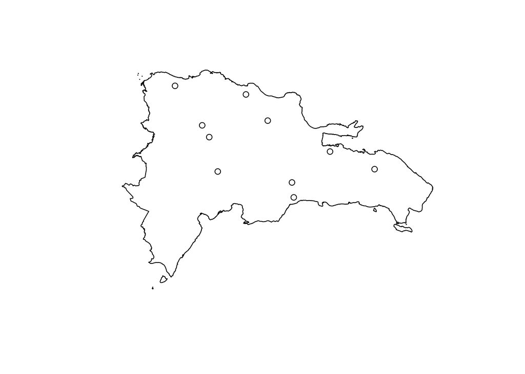

```r
plot(rd %>% st_as_sfc())
plot(puntos, add = TRUE)
```

## Paso 2. Selecciona tus cinco variables cuantitativas

Se te asignarán cinco variables cuantitativas según tu semilla. Usa este código para generarlas.

```r
{set.seed(mi_aleatorizacion)

  v_topo <- tipos_var$Fuente[grepl('G90-PE|CGIAR|YINS', tipos_var$Fuente)]

  v_bio_1_11 <- tipos_var$Fuente[
    grepl(paste0('CHELSA_bio', 1:11, '_', collapse = '|'), tipos_var$Fuente)
  ]

  v_bio_12_19 <- tipos_var$Fuente[
    grepl(paste0('CHELSA_bio', 12:19, '_', collapse = '|'), tipos_var$Fuente)
  ]

  v_bio_todas <- tipos_var$Fuente[
    grepl(paste0('CHELSA_bio', 1:19, '_', collapse = '|'), tipos_var$Fuente)
  ]

  set.seed(mi_aleatorizacion)

  sel_topo <- sample(v_topo, 2)
  sel_bio_1_11 <- sample(v_bio_1_11, 1)
  sel_bio_12_19 <- sample(v_bio_12_19, 1)

  v_bio_restantes <- setdiff(v_bio_todas, c(sel_bio_1_11, sel_bio_12_19))
  sel_bio_extra <- sample(v_bio_restantes, 1)

  fuentes_cuan_sel <- c(
    sel_topo,
    sel_bio_1_11,
    sel_bio_12_19,
    sel_bio_extra
  )
}
cat('Estos fueron mis archivos seleccionados', fuentes_cuan_sel, sep = '\n')
```

```
## Estos fueron mis archivos seleccionados
## data/G90-PENDIENTE.tif
## data/CGIAR-ELEVACION.tif
## data/CHELSA_bio4_1981-2010_V21.tif
## data/CHELSA_bio19_1981-2010_V21.tif
## data/CHELSA_bio6_1981-2010_V21.tif
```

> Si alguna combinación no produce la distribución esperada entre tipos de variables, puedes ajustar el muestreo manteniendo siempre el criterio de reproducibilidad con semilla y dejando constancia del cambio en materiales y métodos.

## Paso 3. Extrae los valores de los rásters en tus puntos

Usando tus 10 puntos, extrae los valores de las cinco variables asignadas.

Con `sapply`:

```r
df_valores_cuan_sel_sapply <- sapply(
  fuentes_cuan_sel,
  function(archivo) {
    r_i <- raster(archivo)
    raster::extract(x = r_i, y = puntos)
  }
) %>%
  as.data.frame() %>%
  setNames(gsub('.tif', '', basename(fuentes_cuan_sel)))
```

Con bucle `for`:

```r
df_resultados <- list()
for (archivo in fuentes_cuan_sel) {
  r_a <- raster(archivo)
  v <- raster::extract(x = r_a, y = puntos)
  df_resultados[[archivo]] <- v
}

df_valores_cuan_sel_for <- df_resultados %>%
  as.data.frame() %>%
  setNames(gsub('.tif', '', basename(fuentes_cuan_sel)))
```

Comprueba que ambos procedimientos devuelven el mismo resultado.

```r
all.equal(df_valores_cuan_sel_sapply, df_valores_cuan_sel_for)
```

```
## [1] TRUE
```

Muestra tu tabla de valores extraídos.

```r
df_valores_cuan_sel_for %>%
  knitr::kable(align = 'c', digits = 2)
```

| G90-PENDIENTE | CGIAR-ELEVACION | CHELSA_bio4_1981-2010_V21 | CHELSA_bio19_1981-2010_V21 | CHELSA_bio6_1981-2010_V21 |
| --- | --- | --- | --- | --- |
| 8.93 | 989.46 | 1053 | 1568 | 2884 |
| 20.19 | 596.50 | 1386 | 2027 | 2898 |
| 2.89 | 42.98 | 1014 | 2188 | 2931 |
| 1.31 | 197.07 | 1388 | 3743 | 2912 |
| 3.24 | 153.91 | 1172 | 2505 | 2935 |
| 2.24 | 56.02 | 1107 | 2573 | 2922 |
| 0.80 | 79.21 | 1621 | 1515 | 2937 |
| 20.32 | 1326.37 | 1234 | 2443 | 2859 |
| 4.08 | 93.09 | 1292 | 4097 | 2941 |
| 4.75 | 204.55 | 1231 | 4145 | 2921 |

### Conversión de variables CHELSA a unidades reales

Las variables CHELSA usan factor de escala y, en algunos casos, *offset*. Corrige sus valores con este bloque.

```r
vars_offset <- paste0('_bio', c(1, 5:6, 8:11), '_')

df_valores_cuan_sel_reales <- df_valores_cuan_sel_sapply %>%
  mutate(
    across(matches('bio\\d+'), ~ . * 0.1),
    across(matches(paste(vars_offset, collapse = '|')), ~ . - 273.15)
  )
```

```r
df_valores_cuan_sel_reales %>%
  knitr::kable(align = 'c', digits = 2)
```

| G90-PENDIENTE | CGIAR-ELEVACION | CHELSA_bio4_1981-2010_V21 | CHELSA_bio19_1981-2010_V21 | CHELSA_bio6_1981-2010_V21 |
| --- | --- | --- | --- | --- |
| 8.93 | 989.46 | 105.3 | 156.8 | 15.25 |
| 20.19 | 596.50 | 138.6 | 202.7 | 16.65 |
| 2.89 | 42.98 | 101.4 | 218.8 | 19.95 |
| 1.31 | 197.07 | 138.8 | 374.3 | 18.05 |
| 3.24 | 153.91 | 117.2 | 250.5 | 20.35 |
| 2.24 | 56.02 | 110.7 | 257.3 | 19.05 |
| 0.80 | 79.21 | 162.1 | 151.5 | 20.55 |
| 20.32 | 1326.37 | 123.4 | 244.3 | 12.75 |
| 4.08 | 93.09 | 129.2 | 409.7 | 20.95 |
| 4.75 | 204.55 | 123.1 | 414.5 | 18.95 |

Esta tabla será una de las bases de tu sección de **resultados**.

## Paso 4. Construye e interpreta la matriz de correlación

Construye una matriz de correlación de Pearson con tus cinco variables cuantitativas.

```r
correlacion <- cor(df_valores_cuan_sel_reales)
correlacion_inferior <- correlacion
correlacion_inferior[upper.tri(correlacion_inferior, diag = TRUE)] <- NA
correlacion_inferior <- round(correlacion_inferior, 3)
correlacion_inferior[is.na(correlacion_inferior)] <- ''
```

```r
correlacion_inferior %>% knitr::kable()
```

|  | G90-PENDIENTE | CGIAR-ELEVACION | CHELSA_bio4_1981-2010_V21 | CHELSA_bio19_1981-2010_V21 | CHELSA_bio6_1981-2010_V21 |
| --- | --- | --- | --- | --- | --- |
| G90-PENDIENTE |  |  |  |  |  |
| CGIAR-ELEVACION | 0.819 |  |  |  |  |
| CHELSA_bio4_1981-2010_V21 | -0.002 | -0.146 |  |  |  |
| CHELSA_bio19_1981-2010_V21 | -0.26 | -0.33 | 0.016 |  |  |
| CHELSA_bio6_1981-2010_V21 | -0.803 | -0.957 | 0.163 | 0.273 |  |

Identifica el **par de variables con mayor valor absoluto del coeficiente de correlación de Pearson**. Ese par será el núcleo de tu análisis posterior y de tu narración científica.

Puedes ayudarte con este bloque:

```r
cor_mat <- cor(df_valores_cuan_sel_reales)
cor_abs <- abs(cor_mat)
cor_abs[upper.tri(cor_abs, diag = TRUE)] <- NA
idx <- which(cor_abs == max(cor_abs, na.rm = TRUE), arr.ind = TRUE)[1, ]
var_x_nombre <- colnames(cor_mat)[idx[2]]
var_y_nombre <- colnames(cor_mat)[idx[1]]
coef_cor_max <- cor_mat[idx[1], idx[2]]

var_x_nombre
```

```
## [1] "CGIAR-ELEVACION"
```

```r
var_y_nombre
```

```
## [1] "CHELSA_bio6_1981-2010_V21"
```

```r
coef_cor_max
```

```
## [1] -0.9572431
```

## Paso 5. Representa gráficamente el par de variables seleccionado

Construye un gráfico de dispersión del par de variables con mayor correlación absoluta e incorpora la recta ajustada.

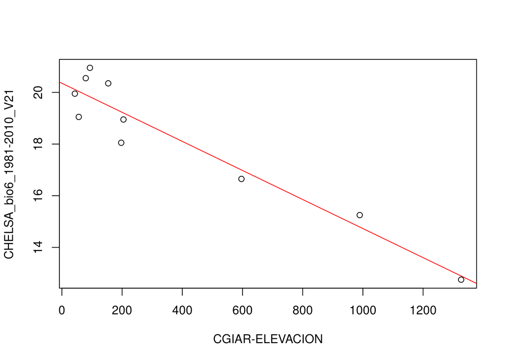

```r
var1 <- df_valores_cuan_sel_reales[[var_x_nombre]]
var2 <- df_valores_cuan_sel_reales[[var_y_nombre]]

plot(var1, var2, xlab = var_x_nombre, ylab = var_y_nombre)
abline(lm(var2 ~ var1), col = 'red')
```

Este gráfico debe aparecer en tu manuscrito como una **figura interpretada**, no sólo como salida técnica.

## Paso 6. Ajusta un modelo de regresión lineal simple

Usando ese mismo par de variables, construye un modelo de regresión lineal simple. Debes decidir cuál variable funcionará como respuesta y cuál como predictora, y justificar esa decisión.

```r
x <- df_valores_cuan_sel_reales[[var_x_nombre]]
y <- df_valores_cuan_sel_reales[[var_y_nombre]]

modelo <- lm(y ~ x)
summary(modelo)
```

```
##
## Call:
## lm(formula = y ~ x)
##
## Residuals:
##     Min      1Q  Median      3Q     Max
## -1.1948 -0.3241 -0.1519  0.5973  1.1202
##
## Coefficients:
##              Estimate Std. Error t value Pr(>|t|)
## (Intercept) 20.353384   0.340974  59.692 6.89e-12 ***
## x           -0.005625   0.000601  -9.359 1.39e-05 ***
## ---
## Signif. codes:  0 '***' 0.001 '**' 0.01 '*' 0.05 '.' 0.1 ' ' 1
##
## Residual standard error: 0.8109 on 8 degrees of freedom
## Multiple R-squared:  0.9163, Adjusted R-squared:  0.9059
## F-statistic:  87.6 on 1 and 8 DF,  p-value: 1.388e-05
```

> Puedes probar salidas estilizadas, especialmente para el manuscrito, usando el paquete `gtsummary` o el paquete `xtab`. Igualmente, para representar gráficos de dispersión estilizados, puedes usar paquetes que los muestran incluso con el modelo generado en la forma `y ~ ax + b`.

Extrae e informa al menos:

- intercepto;
- pendiente;
- signo de la relación;
- magnitud aproximada del ajuste;
- sentido biogeográfico o ambiental de esa relación.

Puedes obtener los coeficientes así:

```r
coef(modelo)
```

```
## (Intercept)           x
## 20.35338371 -0.00562528
```

Y puedes añadir una tabla simple con valores observados y ajustados si lo consideras útil.

## Paso 7. Convierte el análisis en un manuscrito

Una vez tengas los resultados anteriores, debes convertirlos en un trabajo con lógica científica. DETENTE UN MOMENTO AQUÍ, IMPORTANTE, REITERANDO. No sigas adelante sin haber pensado bien qué historia quieres contar con tus datos. No redactes la introducción ni los métodos sin tener claro qué pregunta vas a responder, qué hipótesis vas a probar y qué objetivos vas a perseguir. En materiales y métodos, y en resultados, usa gráficos y salidas vistosas propias de un manuscrito. Nada de pegar salida de la consola, gráficos básicos de R, o mapas mudos; no, eso no se puede publicar. Debes construir un manuscrito con figuras y tablas apropiadas, y R dispone de las herramientas para hacerlo. No te conformes con lo mínimo, haz un esfuerzo por construir un manuscrito que cumpla con estándares básicos de comunicación científica.

### Qué debes hacer

A partir del patrón observado en tus datos:

- proponer una **pregunta de investigación**;
- formular una **hipótesis**;
- redactar **objetivo general** y, si lo deseas, objetivos específicos;
- construir una narración coherente entre datos, métodos, resultados e interpretación.

Tu pregunta no debe ser inventada al azar ni desconectada del análisis. Debe surgir de la relación observada entre las variables seleccionadas.

Ejemplos del tipo de pregunta que podría surgir:

- ¿Existe una relación lineal entre la elevación y una variable bioclimática en los puntos seleccionados?
- ¿Qué tan fuerte es la asociación entre dos variables del medio físico en una muestra espacial aleatoria de la República Dominicana?
- ¿Puede una variable topográfica actuar como predictora simple de una variable climática en los puntos analizados?

No copies estos ejemplos literalmente salvo que realmente coincidan con tu caso. Debes adaptarlos a tus variables concretas.

# Estructura del manuscrito

## Introducción

Extensión sugerida: **3 párrafos**.

Debes:

- explicar qué se entiende por medio físico o variables ambientales en biogeografía;
- explicar por qué la relación entre variables ambientales puede ser importante para comprender patrones ecológicos o biogeográficos;
- presentar la pregunta, hipótesis y objetivos de tu trabajo;
- introducir brevemente las variables concretas que analizarás.

La introducción debe incluir **al menos tres citas bibliográficas**.

## Materiales y métodos

Extensión sugerida: **2–3 párrafos**.

Debes describir:

- el área general de estudio (República Dominicana);
- el procedimiento de generación de puntos aleatorios mediante semilla;
- las fuentes ráster utilizadas;
- la extracción de valores en puntos;
- el análisis de correlación;
- el ajuste del modelo de regresión lineal simple;
- el software usado, especialmente R y los paquetes principales.

No adelantes resultados en esta sección.

Si incluyes tablas, diagramas o esquemas metodológicos, debes referirte a ellos mediante **referencias cruzadas**.

## Resultados

Extensión sugerida: **1–2 párrafos**, además de tablas y figuras.

Debes presentar, como mínimo:

- la tabla de variables seleccionadas o la tabla de valores extraídos;
- la matriz de correlación;
- el par de variables escogido;
- el gráfico de dispersión;
- los coeficientes principales del modelo lineal.

Aquí debes **mostrar** qué obtuviste. La interpretación extensa corresponde sobre todo a la discusión.

## Discusión

Extensión sugerida: **2 párrafos**.

Debes:

- indicar si tus resultados respaldan o no tu hipótesis;
- interpretar el sentido del coeficiente de correlación y de la pendiente del modelo;
- discutir la plausibilidad ambiental o biogeográfica del patrón observado;
- mencionar limitaciones, por ejemplo el tamaño muestral, la naturaleza exploratoria del ejercicio y el hecho de que la selección deriva de una aleatorización.

## Conclusiones

Redacta una conclusión breve y directa.

Debe sintetizar:

- qué relación identificaste;
- qué aprendiste del uso de R para este tipo de análisis;
- qué limitaciones y posibilidades futuras deja el ejercicio.

## Referencias

Todas las referencias citadas deben aparecer en la sección final.

Debes utilizar **formato APA 7** mediante **BibTeX**. La plantilla, al tejerse, se encarga de adaptar las citas y los estilos a APA 7, por lo que sólo tendrás que ocuparte de buscar fuentes y citarlas adecuadamente.

# Recomendaciones de redacción

Usa una voz activa o pasiva de forma consistente.

Ejemplos:

**Voz activa**

- Analicé los datos ambientales utilizando R.
- Los resultados muestran una asociación negativa entre las variables.

**Voz pasiva**

- Los datos ambientales fueron analizados utilizando R.
- Se observó una asociación negativa entre las variables.

Ambas formas son aceptables en redacción científica.

Evita:

- narrar el manuscrito como una lista de comandos;
- confundir correlación con causalidad;
- afirmar mecanismos ecológicos complejos que no puedes sostener con este análisis simple.

## Uso de inteligencia artificial

Está permitido utilizar herramientas de IA.

Sin embargo:

- úsala como **tutor**, no como redactor automático;
- verifica conceptos, código y referencias;
- no copies texto sin revisarlo;
- no inventes citas bibliográficas;
- recuerda que el producto final debe reflejar comprensión real de tus análisis.

# Organización del trabajo (3 días)

## Día 1 — Generación y análisis

Debes completar:

- elección y anuncio de tu semilla;
- generación de puntos;
- selección de variables;
- extracción de valores;
- matriz de correlación;
- selección del par de variables;
- ajuste inicial del modelo de regresión.

Avanzar también en:

- guardado de figuras;
- tablas de resultados;
- notas para materiales y métodos.

## Día 2 — Redacción del manuscrito

Debes redactar:

- introducción;
- materiales y métodos;
- resultados;
- discusión;
- conclusiones.

Además:

- inserta figuras y tablas finales;
- revisa citas y referencias;
- compila el PDF final.

## Día 3 — Presentación

Debes completar:

- manuscrito final;
- diapositivas;
- preparación de la defensa oral.

Realizarás:

- exposición oral en clase.

# Criterios de evaluación del manuscrito

| Criterio | Nivel 1 | Nivel 2 | Nivel 3 | Nivel 4 |
| --- | --- | --- | --- | --- |
| Análisis espacial y extracción | Incorrecto o incompleto | Básico | Correcto | Correcto y bien documentado |
| Correlación y regresión | Incorrectas | Aplicación parcial | Aplicación correcta | Aplicación rigurosa y bien explicada |
| Uso de R y reproducibilidad | Muy limitado | Adecuado | Buen manejo | Manejo avanzado y totalmente claro |
| Redacción científica | Deficiente | Clara pero simple | Fluida | Muy sólida |
| Estructura del manuscrito | Incorrecta | Básica | Bien organizada | Impecable |
| Figuras y tablas | Ausentes o incorrectas | Uso básico | Buena integración | Integración excelente |
| Citas y referencias | Incorrectas | Algunas correctas | Mayormente correctas | Uso correcto y consistente de APA 7 |
| Coherencia entre datos y argumentación | Débil | Parcial | Coherente | Muy convincente |

# Criterios de evaluación de la presentación oral

| Criterio | Nivel 1 | Nivel 2 | Nivel 3 | Nivel 4 |
| --- | --- | --- | --- | --- |
| Claridad de la exposición | Difícil de seguir | Comprensible | Clara | Muy clara y bien estructurada |
| Uso de diapositivas | Confusas | Básicas | Buen apoyo visual | Excelente diseño visual |
| Explicación del método | Poco clara | Parcial | Correcta | Muy bien explicada |
| Interpretación de resultados | Ausente o débil | Básica | Adecuada | Profunda y crítica |
| Manejo del tiempo | Fuera del tiempo | Ligeramente fuera | Ajustado | Perfectamente ajustado |
| Capacidad de defensa | No responde | Respuestas limitadas | Responde correctamente | Argumenta con claridad y seguridad |
| Coherencia entre manuscrito y oral | Baja | Parcial | Buena | Muy alta |

# Resumen

En esta práctica debes:

1. trabajar en **R**;
2. generar **10 puntos aleatorios** con tu semilla;
3. extraer valores de **5 variables cuantitativas**;
4. construir una **matriz de correlación**;
5. elegir el par con **mayor correlación absoluta**;
6. ajustar una **regresión lineal simple**;
7. convertir esos resultados en un **manuscrito científico reproducible**;
8. preparar **diapositivas** y una **presentación oral**.

La práctica no consiste en resolver ejercicios separados, sino en **transformar un análisis ambiental exploratorio en una pieza breve de comunicación científica**.